# Bernoulli and Binomial Distributions: R Code

Wednesday, October 20, 2021 @ 12:24 PM

## Before We Begin…

These slides are not meant to be standalone information. You should take notes to flesh out the contents. I recommend that you create an R Markdown document where you can combine information and code from the slides and your own additional notes and explorations to make connections.

**Related Materials**

- Appendix A of *Mathematical Statistics with Resampling and R, 2<sup>nd</sup> Ed.* (Review of Probability)
- DataCamp [Foundations of Probability in R](https://learn.datacamp.com/courses/foundations-of-probability-in-r)
- [Bernoulli and Binomial Distributions: The Math](https://stat-jet-asu.github.io/StatisticalDataAnalysis1/Slides/BinomialDistributionTheory.html) class slides

## Index

- Slides 02-03 — Materials & Index
- Slides 04-13 — Calculating PMF and CDF
  - Slides 05-07 — General Model and PMF
  - Slides 08-13 — CDF and Inverse CDF
- Slides 14-19 — Simulating a Binomial
  - Slides 15-17 — Generating and Tabulating
  - Slides 18-19 — Plotting and Summarizing
- Slides 20-28 — Creating a Distribution “Table” and Plots
  - Slides 21-25 — General Algorithm and `R` Code
  - Slides 26-28 — Example for 20 Fair Coin Flips

## Calculating PMF and CDF

## The Binomial Model

\[X \sim Bin(n,p)\]

```
x = number of successes = {0, 1, 2, ..., n}
n = number of trials
p = probability of success on a single trial
1 - p = probability of failure on a single trial
```

\[f(x) = P(X = x) = {n \choose x}p^x(1-p)^{n-x}\]

\[F(x)=P(X \leq x) = \sum\limits_{i=0}^x f(x) = \sum\limits_{i=0}^x {n \choose i}p^i(1-p)^{n-i}\]

\[E[X] = np \text{ and }Var[X] = np(1-p)\]

## Calculating the pmf or f(x)

The `dbinom()` function is used to calculate pmf probabilities for the binomial distribution.

\(P(X = x)\) = \(f(x,n,p) \rightarrow\) `dbinom(x, size, prob)` in `R`

Consider our biased coin example where \(X \sim Bin(3, 0.7)\).

```r
dbinom(1, 3, 0.7)   # P(X = 1 head)
```

```
[1] 0.189
```

```r
dbinom(3, 3, 0.7)   # P(X = 3 heads)
```

```
[1] 0.343
```

## Vectorized Calculations

The `dbinom` function can accept vectors as input. It loops over all values in the input vector and outputs a vector the same length. What are the probabilities for \(x = \{0, 1, 2, 3\}\) heads if we have a fair coin? We can compute the entire pdf at once.

Recall that in `R` we can easily make a vector of integers using the `:` operator, without needing to use `c()`.

```r
dbinom(0:3, 3, 0.5)   # compute all probabilities at the same time
```

```
[1] 0.125 0.375 0.375 0.125
```

Notice that when \(p = 0.5\), the distribution is symmetric. Refer to \(f(x)\) and see if you can figure out why that is true.

## Calculating the CDF or F(x)

The `pbinom()` function is used to calculate CDF probabilities for the binomial distribution. It also accepts vector inputs.

\(P(X \leq x)\) = \(F(x,n,p) \rightarrow\) `pbinom(q, size, prob)` in `R`

```r
pbinom(0:3, 3, 0.7)   # biased coin, x = {0, 1, 2, 3} heads
```

```
[1] 0.027 0.216 0.657 1.000
```

```r
pbinom(0:3, 3, 0.5)   # fair coin, x = {0, 1, 2, 3} heads
```

```
[1] 0.125 0.500 0.875 1.000
```

The CDF for the fair coin also has a kind of symmetry to it. Why is that the case?

## The Upper Tail of the Distribution

```r
pbinom(2, 3, 0.7)    # probability of 0, 1, or 2 heads
```

```
[1] 0.657
```

```r
1 - pbinom(2, 3, 0.7)   # probability of more than 2 heads
```

```
[1] 0.343
```

```r
pbinom(2, 3, 0.7, lower.tail = FALSE)   # better code
```

```
[1] 0.343
```

Pay close attention to \(<\) vs \(\leq\) and \(>\) vs \(\geq\) with `pbinom()`. We are dealing with discrete sample spaces here.

For three tosses of our fair coin…

```r
pbinom(0:3, 3, 0.5)   # P(X <= x) for all possible x
```

```
[1] 0.125 0.500 0.875 1.000
```

```r
pbinom(0:3, 3, 0.5, lower.tail = FALSE)   # P(X > x)
```

```
[1] 0.875 0.500 0.125 0.000
```

```r
pbinom(0:3, 3, 0.5) + pbinom(0:3, 3, 0.5, lower.tail = FALSE)
```

```
[1] 1 1 1 1
```

The two halves sum to 1. Voila! Can you picture it on a graph?

Can you show on the pmf graph below the difference between `lower.tail = TRUE` and `lower.tail = FALSE` for a given \(x\)?

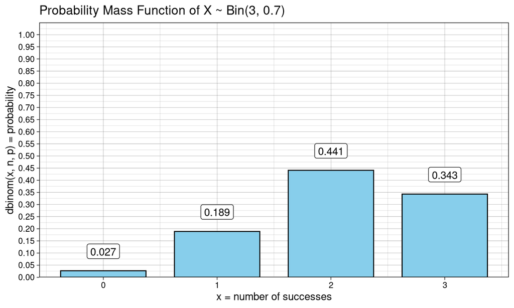

The areas included in the calculation are shaded in solid black.

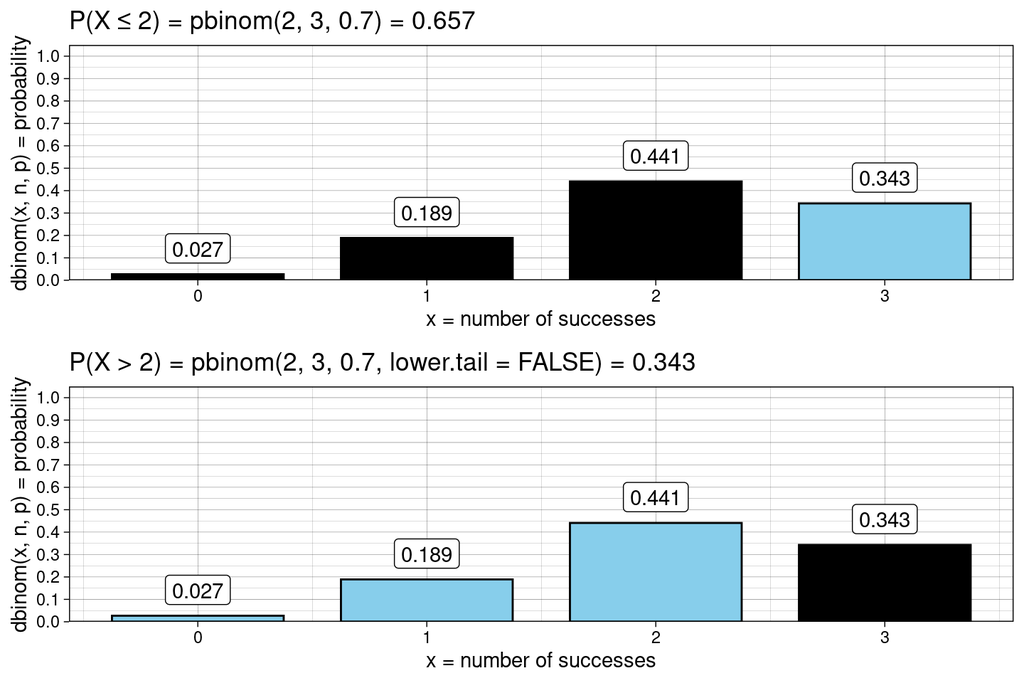

## Calculating the Inverse of the CDF

Until now, we have been finding probabilities associated with given values of \(x\). What if we have the probability and need \(x\)? For a given quantile (percentile), the inverse CDF gives us the \(x\) that makes \(P(X \leq x) = quantile\) (approximately) true.

\(q^{th}\) percentile = \(F^{-1}(x,n,p) \rightarrow\) `qbinom(p, size, prob)` in `R`

```r
qbinom(0.25, 3, 0.7)   # 25th percentile of X ~ Bin(3, 0.7)
```

```
[1] 2
```

```r
qbinom(0.75, 3, 0.7)   # 75th percentile of X ~ Bin(3, 0.7)
```

```
[1] 3
```

## Simulating a Binomial

## Generating Random Values

To generate a (*pseudo*)random sample from a given binomial distribution, use `rbinom(n, size, prob)`. The binomial \(n\) parameter is called *size* in `R`’s functions, because \(n\) is standard notation for sample size in statistics.

Simulate 20 random values from biased coin \(X \sim Bin(3, 0.7)\)

```r
rbinom(20, 3, 0.7)
```

```
 [1] 2 2 2 2 2 2 3 3 0 2 2 1 3 2 3 1 1 3 2 2
```

Each output value in this random sample is \(x\) = *number of heads* (successes) in a sequence of 3 flips. We have 20 replicates of the “experiment” of flipping 3 coins.

## Tabulating Random Samples

For a discrete random variable with a small number of possible values, we can tabulate the simulated values. How close are the simulated proportions to the theoretical probabilities?

```r
binom_sample <- tibble(x = rbinom(10^5, 3, 0.7))   # 100,000 samples
binom_sample %>%
  count(x) %>%
  mutate(proportion = prop.table(n))
```

```
# A tibble: 4 × 3
      x     n proportion
  <int> <int>      <dbl>
1     0  2713     0.0271
2     1 19074     0.191
3     2 43900     0.439
4     3 34313     0.343
```

## Empirical vs Theoretical

Values obtained from experimentation, including simulation, are *empirical* values. Empirical proportions can be used to estimate unknown probabilities.

```r
binom_sample %>%
  count(x) %>%
  mutate(empirical   = prop.table(n),
         theoretical = dbinom(0:3, 3, 0.7))
```

```
# A tibble: 4 × 4
      x     n empirical theoretical
  <int> <int>     <dbl>       <dbl>
1     0  2713    0.0271       0.027
2     1 19074    0.191        0.189
3     2 43900    0.439        0.441
4     3 34313    0.343        0.343
```

## Plotting Random Samples

For a discrete random variable with a small number of values, we can create a bar plot. More often, we will use a histogram to accommodate a larger range of possible x values.

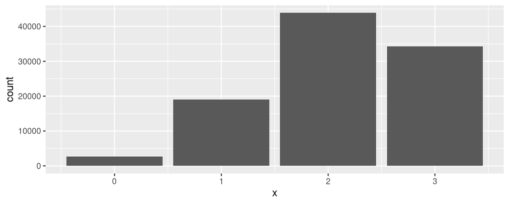

```r
ggplot(binom_sample, aes(x = x)) + geom_bar()   # add formatting
```

## Summarizing Random Samples

How close are these values to the theoretical E[X] and Var[X]?

```r
binom_sample %>%
  summarize(samples = n(),
            mean_x  = mean(x),
            var_x   = var(x))
```

```
# A tibble: 1 × 3
  samples mean_x var_x
    <int>  <dbl> <dbl>
1  100000   2.10 0.633
```

As the sample size approaches \(\infty\), sample mean \(\bar{x}\) and sample variance \(s^2\) converge to E[X] and Var[X]. Because of this, we can use simulation / random sampling to *estimate* parameters when the underlying distribution is not known.

## Distribution “Table” and Plots of the PMF and CDF

## Creating a Distribution “Table”

```r
n <- 3     # enter n
p <- 0.7   # enter p
distTable <- tibble(x   = 0:n,               # x = {0, 1, ... , n}
                    pmf = dbinom(x, n, p),   # calculate for all x
                    CDF = pbinom(x, n, p))   # calculate for all x
distTable
```

```
# A tibble: 4 × 3
      x   pmf   CDF
  <int> <dbl> <dbl>
1     0 0.027 0.027
2     1 0.189 0.216
3     2 0.441 0.657
4     3 0.343 1
```

You can format for digits and appearance with [`kable()`](https://cran.r-project.org/web/packages/kableExtra/vignettes/awesome_table_in_html.html).

## Creating a Plot of the PMF

The plot uses the \(n\) and \(p\) we input and `distTable` object.

```r
breakby <- 1   # choose spacing for the x-axis tick marks

ggplot(distTable, aes(x = x, y = pmf)) +
  geom_col(fill = "skyblue", color = "black", width = 1) +
  scale_x_continuous(breaks = seq(from = 0, to = n, by = breakby)) +
  labs(title = sprintf("PMF of X ~ Bin(%1.0f, %1.1f)", n, p),
       x = "x",
       y = "f(x)") +
  theme_linedraw()
```

You can add other formatting or change themes as desired.

To display more decimal places for \(p\) in the plot title, change %1.1f to %1.*decimalplaces*f in the code (e.g., %1.3f for three).

## The Output

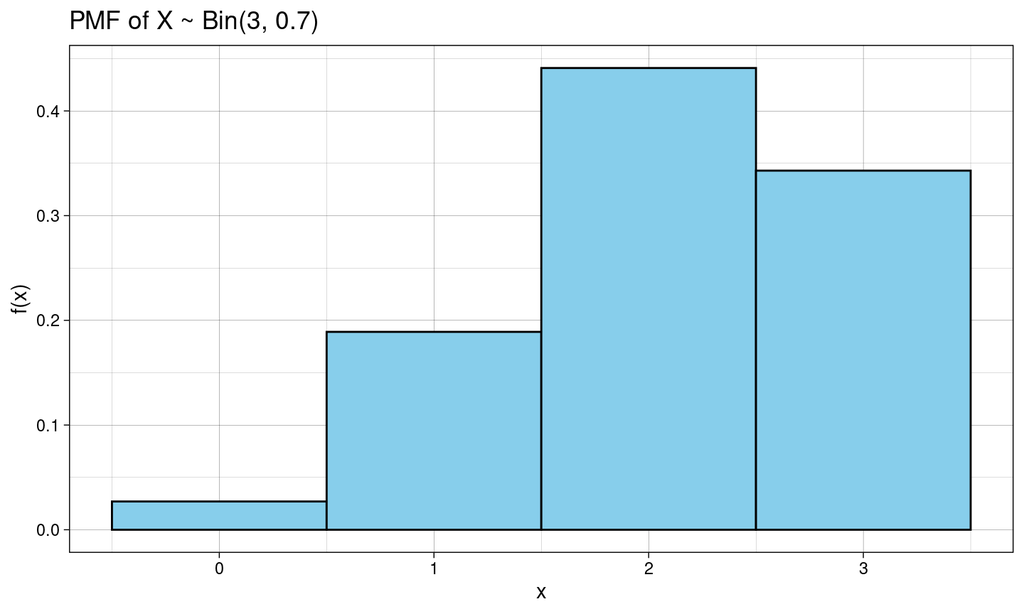

## Creating a Plot of the CDF

The plot uses the \(n\) and \(p\) we input and `distTable` object.

```r
breakby <- 1   # choose spacing for the x-axis tick marks

ggplot(distTable, aes(x = x, y = CDF)) +
  geom_col(fill = "skyblue", color = "black", width = 1) +
  scale_x_continuous(breaks = seq(from = 0, to = n, by = breakby)) +
  labs(title = sprintf("CFD of X ~ Bin(%1.0f, %1.1f)", n, p),
       x = "x",
       y = "F(x)") +
  theme_linedraw()
```

Add additional formatting or themes as desired.

To display more decimal places for \(p\) in the plot title, change %1.1f to %1.*decimalplaces*f in the code (e.g., %1.3f for three).

## The Output

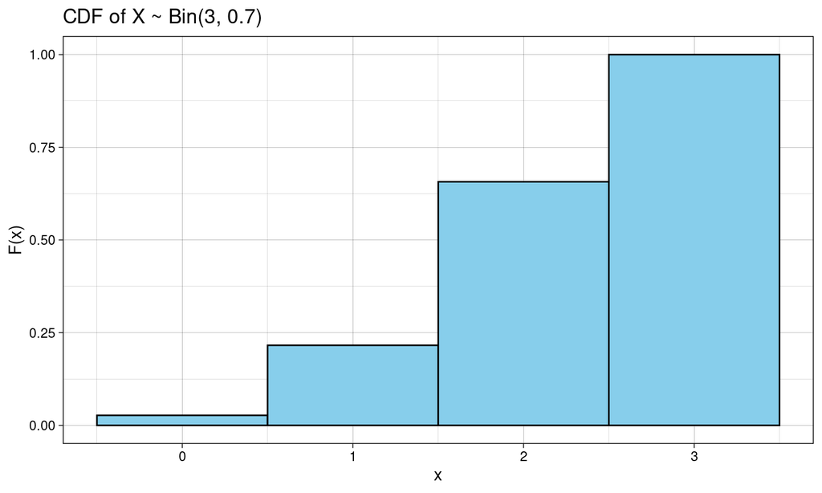

## Example for 20 Fair Coin Flips

```r
n <- 20
p <- 0.5
distTable <- tibble(x   = 0:n,
                    pmf = dbinom(x, n, p),
                    CDF = pbinom(x, n, p))
head(distTable, 6)   # the full table is too large for the slide
```

```
# A tibble: 6 × 3
      x         pmf         CDF
  <int>       <dbl>       <dbl>
1     0 0.000000954 0.000000954
2     1 0.0000191   0.0000200
3     2 0.000181    0.000201
4     3 0.00109     0.00129
5     4 0.00462     0.00591
6     5 0.0148      0.0207
```

## The pmf Plot

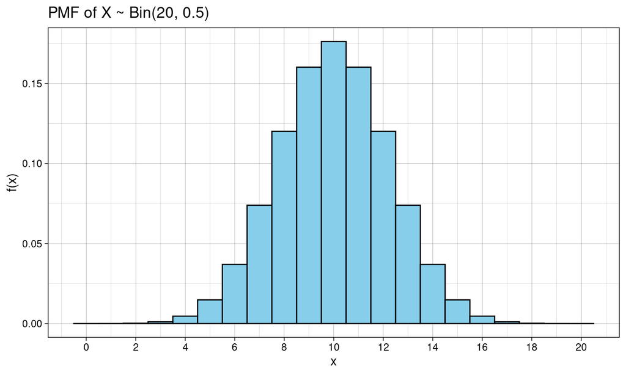

For the future: What shape does this (approximately) look like?

## The CDF Plot

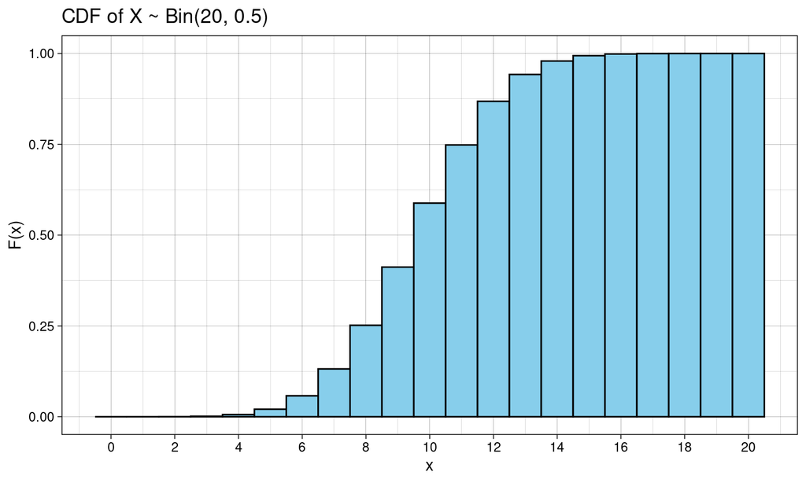

For the future: Notice the symmetric logistic (S-curve) shape.